# MOMA - Multi Omic Master Regulator Analysis

Evan Paull and Sunny Jones

# Introduction and Background

MOMA is a tool for inferring connections between Master Regulator proteins and genomic driver events in cancer. Master regulators are regulatory proteins (primarily transcription factors and co-transcription factors) that control cell state. In the case of cancer and other disease states transcription factors have been shown to be key drivers of maintaining the disease state and can be targets for interventions. Often these master regulators are not mutated themselves but are downstream of mutations and other genomic alterations that ultimately dysregulate the normal activity of that regulator. MOMA uses multiple inputs of information to infer these connections and to improve the predictive value of the master regulator analysis.

*For more information on Master Regulators and our tool for calculating their values see the paper published on VIPER in Nature Genetics in 2016* paper // package.

# Running MOMA

## Getting Started

First load the library into the R session. Make sure all the other dependent packages have already been installed to ensure full functionality, including graphics and plotting functions.

```r
knitr::opts_chunk$set(warning = FALSE)
library(moma)
```

Explore the test data, and confirm that we have 100 test samples and 2506 VIPER inferred proteins in the test viper matrix. This was generated by using VIPER on the GBM gene expression signature. The matrix has the samples across the columns and the regulators in the rows.

```r
names(gbm.example)
```

```
#>  [1] "vipermat"         "cindy"            "preppi"
#>  [4] "rawsnp"           "fusions"          "gene.loc.mapping"
#>  [7] "clinical"         "fCNV"             "mutSig"
#> [10] "rawcnv"
```

```r
dim(gbm.example$vipermat)
```

```
#> [1] 2506  100
```

```r
gbm.example$vipermat[1:3, 1:3]
```

```
#>     TCGA-14-1825-01 TCGA-76-4931-01 TCGA-06-5418-01
#> 165      -3.0369845       0.9518478       1.1485397
#> 196      -2.4667300      -3.2473674      -0.5219556
#> 257       0.7872116       0.7562328       0.6428189
```

```r
pathways <- list()
pathways[['cindy']] = gbm.example$cindy
pathways[['preppi']] = gbm.example$preppi
```

## Generating the **MOMA** object

Start by loading in all the data we have to a MOMA object. The following are data required to do the full analysis:

```r
momaObj <- moma.constructor(gbm.example$vipermat, gbm.example$rawsnp,
        gbm.example$rawcnv, gbm.example$fusions, pathways,
        gene.blacklist=gbm.example$mutSig,
        gene.loc.mapping=gbm.example$gene.loc.mapping)
```

```
#> [1] "Number of samples in VIPER + Mutation data: 100"
#> [1] "Number of samples in VIPER + CNV data: 100"
#> [1] "Number of samples in VIPER + Fusion data: 68"
#> [1] "Common samples with all data analysis:  100"
#> [1] "Checking labels on pathway cindy"
#> [1] "Found labels for  364  TFs in VIPER matrix"
#> [1] "Checking labels on pathway preppi"
#> [1] "Found labels for  2506  TFs in VIPER matrix"
```

## MOMA Analysis on GBM Data

The `makeInteractions()` function will infer robust computational predictions using all the provided data, including the Conditional Inference of Network Dynamics (CINDy) algorithm.  
The option `cindy.only=FALSE` will allow interactions without evidence from CINDy, but with strong evidence from other sources, to be used.

The `Rank()` function will create a final ranking of candidate Master Regulators for this cohort of patient samples.

```r
momaObj$runDIGGIT(fCNV=gbm.example$fCNV)

momaObj$makeInteractions(cindy.only=FALSE)

momaObj$Rank(use.cindy=TRUE)
```

```r
clustering.solutions <- momaObj$Cluster()
```

```
#> [1] "using pearson correlation with weighted vipermat"
#> [1] "testing clustering options, k = 2..15"
```

```r
# pick the 3 cluster solution and save it to the moma Object
momaObj$sample.clustering <- clustering.solutions[[2]]$clustering
```

Genomic saturation analysis is then performed on each cluster with the `saturationCalculation()` function, allowing us to find the key proteins that are downstream of the majority of genomic events in the samples within a particular cluster. These regulators make up that cluster’s Checkpoint.

The results of this analysis can be accessed directly in the following result fields:

- `momaObj$checkpoints`
- `momaObj$genomic.saturation`
- `momaObj$coverage.summaryStats`

These will be used for plotting the genomic saturation curves as well.

```r
momaObj$saturationCalculation()
```

```r
cluster1.checkpoint <- momaObj$checkpoints[[1]]
print (cluster1.checkpoint[1:10])
```

```
#>  [1] "148103" "9817"   "84775"  "10224"  "23660"  "6662"   "57106"
#>  [8] "147741" "26147"  "57615"
```

# Plotting the Results

## Visualizing the Genomic Saturation and Events Plots

The other important results of the analysis are the statisically significant genomic events found to be upstream of each of the checkpoint master regulators. The `makeSaturationPlots()` function takes the subtype specific genomic event interactions calculated in the previous step and makes customizable plots for viewing the results. These are saved to the $identity.plots() part of the momaObj.

```r
momaObj$makeSaturationPlots()
```

```
#> [1] "Number of samples in cluster 1: 22"
#> [1] "Getting events to plot..."
#> [1] "Number of entries in events matrix:  15"
#> [1] "Number of samples in cluster 2: 54"
#> [1] "Getting events to plot..."
#> [1] "Number of entries in events matrix:  15"
#> [1] "Number of samples in cluster 3: 24"
#> [1] "Getting events to plot..."
#> [1] "Number of entries in events matrix:  15"
#> [1] "Threshold for MR cutoff:  32"
#> [1] "Threshold for MR cutoff:  9"
#> [1] "Threshold for MR cutoff:  34"
```

The two plot types are:

- **Genomic Event Bar Plots** : these plot the frequency of the different types of genomic events found to be upstream of the regulators in the checkpoint.
- **Saturation Curves** : these plot the number of regulators needed to capture a certain percentage of genomic events. The inflection points plotted on this graph match up with the cut off for which regulators make up a particular cluster’s checkpoint.

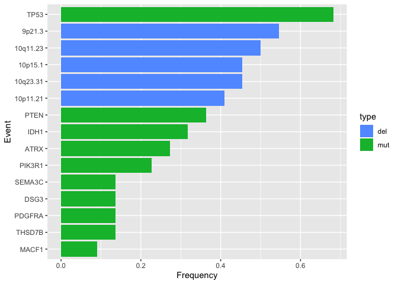

```r
momaObj$identity.plots$bar.plots[[1]]
```

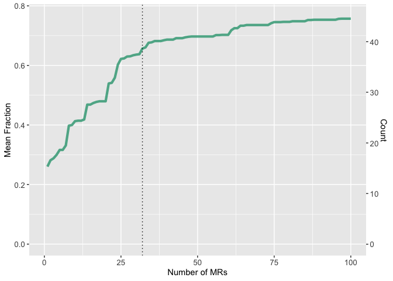

```r
momaObj$identity.plots$curve.plots[[1]]
```

The data for these plots are stored as ggplot objects so layers can be added afterwards for further customization.

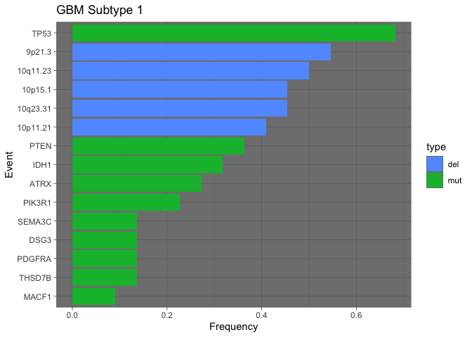

```r
library(ggplot2)
momaObj$identity.plots$bar.plots[[1]] +
  ggtitle("GBM Subtype 1") +
  theme(axis.text.y = element_text(size=5)) +
  theme_dark()
```